# Guía de trabajo variables cuantitativas continuas

Diplomado en Análisis de datos con R para la acuicultura

Dr. José A. Gallardo y Dra. María Angélica Rueda.

Pontificia Universidad Católica de Valparaíso  
jose.gallardo@pucv.cl

27/04/2021

#### **Introducción**

**¿Cuál es la diferencia entre variable y dato?**

Las **variables** son las características que se pueden medir en un individuo o en un ambiente y los **datos** son los valores que puede tomar esa variable.

**¿Qué es una variable aleatoria?**

Es una variable cuyo valor se determina por el azar. Las variables aleatorias se representan por letras mayúsculas (**X**) y sus valores numéricos por letras minúsculas (**xi**).

#### **Objetivos de aprendizaje**

Los objetivos de aprendizaje de esta guía son:

**1**. Observar y predecir una variable aleatoria continua con distribución normal.

**2**. Elaborar un reporte dinámico en formato pdf.

#### **Clasificación de variables cuantitativas**

[output not shown]

#### **Clasificación de variables cualitativas o categóricas**

| Tipo de variable | Descripción |
| --- | --- |
| **Variables nominales:** | Sus valores representan categorías que no obedecen a una clasificación intrínseca. |
| **Variables ordinales:** | Sus valores representan categorías con alguna clasificación intrínseca. |

### **Distribución de una variable**

*Distribución empírica (observación)*: Los datos de una muestra, obtenidos de forma aleatoria de una población, pueden ser usados para observar su comportamiento o distribución.

*Distribución de probabilidad (predicción)*: Las variables aleatorias tienen diferentes distribuciones de probabilidad subyacentes, lo que nos permite predecir su comportamiento y realizar inferencia estadística.

*Distribución normal*: Las variables cuantitativas continuas siguen una distribución normal.

#### **¿Cómo puedo observar y predecir el comportamiento de una variable?**

**Funciones clave**

**1.-** Tabla de distribución de frecuencia  
**table()**

**2.-** Histograma  
**hist()**

**3.-** Gráfica x-y de puntos “p”, lineas “l” o ambas “b”.  
**plot()**

**4.-** Gráfico de cajas y bigotes  
**boxplot()**

**5.-** Mediante la función de densidad empírica  
**density()**

**6.-** Mediante la función de distribución acumulada empírica  
**ecdf()**

#### **¿Qué puedo medir de una variable aleatoria continua?**

**Funciones clave**

**1.-** *Medidas de tendencia central*:

media **mean()** y mediana **median()**.

**2.-** *Medidas de dispersión*:

varianza **var()**, desviación estándar **sd()**.

**3.-** *Concentración de datos en cuantiles*.

**quantile()**.

#### **Librerías a usar en esta guía**

**{stat}** , **{graphics}**, **{readxl}**

## **Ejercicios**

### **Ejercicio 1.** **Elaborar archivo Rmarkdown**

Elabore un archivo o file con extensión **.Rmd** y configurelo para exportar el resultado como un documento dinámico **pdf**. Utilice el siguiente ejemplo para completar la información de **metadatos**: Título: Reporte variables continuas, nombre del autor: Su nombre.

Luego guarde inmediatamente su script como **script_3_nombre_apellido.Rmd**. Al finalizar la actividad deberá exportar y almacenar este *script* en su carpeta drive de tareas.

### **Ejercicio 2.** **Configuración del reporte**

En el primer bloque de códigos o **chunk** configure los comandos de la siguiente manera *knitr::opts_chunk$set(echo = TRUE)* y cargue las librerías **readxl**, **stats** y **graphics** usando la función *library()*.

```r
knitr::opts_chunk$set(echo = TRUE)
library(readxl)
library(stats)
library(graphics)
```

### **Ejercicio 3.** **Borrar información de la plantilla**

Borre los bloques de códigos **R** que se generan automáticamente con cada archivo **.Rmd** y reemplacelos por nuevos bloques de códigos con el botón verde **+C** que se encuentra en la parte superior del panel de códigos.

Ejecute cada uno de los siguientes ejercicios en uno o más bloques de códigos diferentes. Sea ordenado y documente su reporte adecuadamente.

### **Ejercicio 4.** **Importar y explorar datos**

Cree un objeto llamado **dat** e importe el set de datos **shrimp** usando la función *read_excel()* de la librería **readxl**. Explore el set de datos usando las funciones **head()**, **tail**, **summary()** y **str()**.

```r
dat <- read_excel("shrimp.xlsx")
head(dat)
```

```
## # A tibble: 6 x 2
##   sample_id Weight
##       <dbl> <chr>
## 1         1 17.2
## 2         2 18.8
## 3         3 27.8
## 4         4 20.4
## 5         5 20.6
## 6         6 28.6
```

```r
tail(dat)
```

```
## # A tibble: 6 x 2
##   sample_id Weight
##       <dbl> <chr>
## 1       195 13.4
## 2       196 30.0
## 3       197 23.0
## 4       198 13.7
## 5       199 16.9
## 6       200 14.1
```

```r
summary(dat)
```

```
##    sample_id         Weight
##  Min.   :  1.00   Length:200
##  1st Qu.: 50.75   Class :character
##  Median :100.50   Mode  :character
##  Mean   :100.50
##  3rd Qu.:150.25
##  Max.   :200.00
```

```r
str(dat)
```

```
## tibble[,2] [200 x 2] (S3: tbl_df/tbl/data.frame)
##  $ sample_id: num [1:200] 1 2 3 4 5 6 7 8 9 10 ...
##  $ Weight   : chr [1:200] "17.2" "18.8" "27.8" "20.4" ...
```

### **Ejercicio 5.** **Corrección de variables**

Note que en el ejercicio anterior la variable **weight** fue erradamente codificada como caracter o texto (chr) en vez de número. Use la función **as.numeric()** para corregir este error. Vuelva a ejecutar los comandos **summary()** y **str()** para comprobar que las variables están adecuadamente codificadas.

```r
dat$Weight <- as.numeric(dat$Weight)
summary(dat)
```

```
##    sample_id          Weight
##  Min.   :  1.00   Min.   : 8.50
##  1st Qu.: 50.75   1st Qu.:16.90
##  Median :100.50   Median :19.70
##  Mean   :100.50   Mean   :19.96
##  3rd Qu.:150.25   3rd Qu.:22.82
##  Max.   :200.00   Max.   :36.20
```

```r
str(dat)
```

```
## tibble[,2] [200 x 2] (S3: tbl_df/tbl/data.frame)
##  $ sample_id: num [1:200] 1 2 3 4 5 6 7 8 9 10 ...
##  $ Weight   : num [1:200] 17.2 18.8 27.8 20.4 20.6 28.6 22.3 13.7 16.6 17.8 ...
```

### **Ejercicio 6.** **Observar el comportamiento de una variable**

A partir del set de datos **shrimp** elabore un histograma y un boxplot de la variable cuantitativa continua **weight**. Use las funciones **hist()**, **boxplot()**.

Use este comando **par(mfrow=c(1,2))** para unir las gráficas en un solo panel con dos columnas.

Investigue que representa el circulo que aparece en el Boxplot.

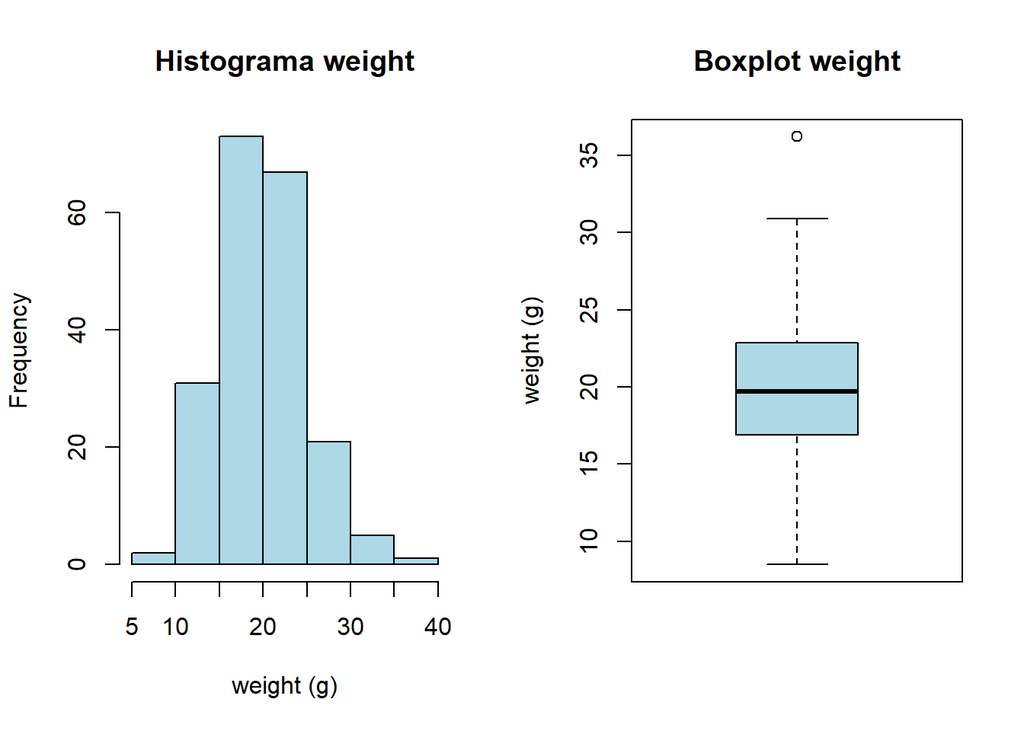

```r
par(mfrow=c(1,2))

hist(dat$Weight, col="light blue", main = "Histograma weight", xlab = "weight (g)")

boxplot(dat$Weight, col="light blue", main = "Boxplot weight", ylab = "weight (g)")
```

### **Ejercicio 6.** **Métricas del set de datos shrimp**

Calcule las siguientes métricas del set de datos: promedio, desviación estándar, rango y cuantiles.

```r
mean(dat$Weight)
```

```
## [1] 19.958
```

```r
sd(dat$Weight)
```

```
## [1] 4.710923
```

```r
range(dat$Weight)
```

```
## [1]  8.5 36.2
```

```r
quantile(dat$Weight)
```

```
##     0%    25%    50%    75%   100%
##  8.500 16.900 19.700 22.825 36.200
```

### **Ejercicio 7.** **Función de densidad**

Usando la función **plot()** elabore:

**a).** Gráfico con la densidad empírica. Debe incluir la función **density()** dentro de plot.

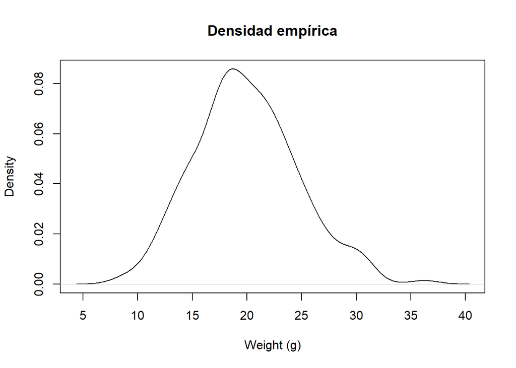

```r
# Densidad empírica.
plot(density(dat$Weight), main="Densidad empírica", xlab="Weight (g)")
```

**b).** Gráfico con la distribución acumulada empírica. Debe incluir la función **ecdf()** dentro de plot.

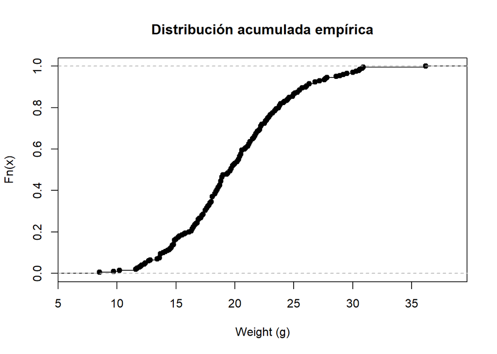

```r
# Distribución acumulada empírica.
plot(ecdf(dat$Weight), main="Distribución acumulada empírica", xlab="Weight (g)")
```

### **Ejercicio 8.** **Crear una función y predecir datos observados**

Utilice la función de distribución acumulada empírica **ecdf()** para determinar que proporción de camarones es menor a 20 g, y que proporción es mayor de 30 g:

**a).** Primero cree una función de distribución acumulada empírica para los datos del peso de sus camarones.

```r
Fn <- ecdf(dat$Weight)
Fn
```

```
## Empirical CDF
## Call: ecdf(dat$Weight)
##  x[1:125] =    8.5,    9.7,   10.2,  ...,   30.9,   36.2
```

**b).** Calcule la proporción de camarones menores de 20 g.

```r
# Fn(x) returns the percentiles for x
paste0(Fn(20)*100, "%")
```

```
## [1] "53%"
```

**c).** Calcule la proporción de camarones mayor a 30 g.

```r
# 1- Fn(x) returns 1 - the percentiles for x
paste0(((1 - Fn(30))*100), "%")
```

```
## [1] "3%"
```

### **Ejercicio 9.** **Proporción de datos entorno a la media**

En la siguiente figura, la linea roja representa 1 de sobre y bajo la media, la linea azul representa la media.

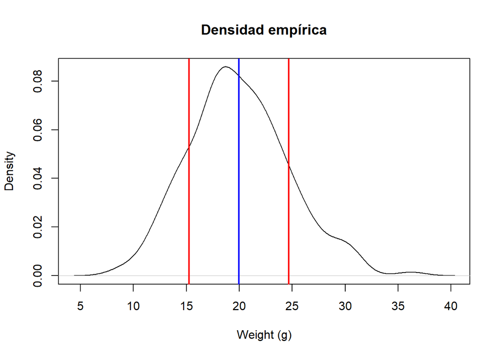

¿Qué proporción de los datos está contenido entre una desviación estándar hacia arriba y hacia abajo de la media?.

**a).** Calcule la proporción de datos 1 desviación estándar sobre la media.

```r
p1 <- 1 - Fn(19.958 + 4.710923)
p1
```

```
## [1] 0.15
```

**b).** Calcule la proporción de datos 1 desviación estándar bajo la media.

```r
p2 <- Fn(19.958 - 4.710923)
p2
```

```
## [1] 0.175
```

**c).** Calcule la proporción de datos entre 1 desviación estándar arriba y abajo de la media multiplicado por 100.

```r
paste0(((1 - (p1 + p2))*100),"%")
```

```
## [1] "67.5%"
```

```r
# Este valor es muy cercano al 68% teórico de una variable con distribución normal.
```